# Gene content analysis L. mudan

Sander Wuyts

28 September 2018

# Initial processing

## Read in all data

```r
# Orthofinder results
gene_pres_abs <- read_tsv("../05_pangenome/Results_Sep03/Orthogroups.GeneCount.csv") %>%
  rename(orthogroup = X1)%>%
  select(-Total) %>%
  gather(key = genome, value = ngenes, -orthogroup) %>%
  filter(! is.na(ngenes) )
# ANI results
genomeTable <- read_tsv("../07_ANI/genomeTableWithClades.tsv") %>%
    mutate(cladeName = case_when(cladeNumber == "clade1" ~ "L. mudanjiangensis",
                               cladeNumber == "clade2" ~ "L. fabifermentans",
                               cladeNumber == "clade3" ~ "L. xiangfangensis",
                               cladeNumber == "clade4" ~ "L. herbarum",
                               cladeNumber_split == "clade5b" ~ "L. pentosus",
                               cladeNumber_split == "clade5a" ~ "clade5a",
                               cladeNumber == "clade6" ~ "L. paraplantarum",
                               cladeNumber == "clade7" ~ "L. plantarum")) %>%
    mutate(cladeName = factor(cladeName, levels = c("L. mudanjiangensis",
                                                  "L. fabifermentans",
                                                  "L. xiangfangensis",
                                                  "L. herbarum",
                                                  "clade5a",
                                                  "L. pentosus",
                                                  "L. paraplantarum",
                                                  "L. plantarum")))  %>%
  rename(genome = Assembly)
# Eggnog results
eggnog <- read_tsv("../08_map_to_eggnog/out/mudan_pan_genome.emapper.annotations", skip = 3) %>%
  rename(orthogroup = `#query_name`,
         functCat = `COG cat`) %>%
  mutate(orthogroup = str_replace(orthogroup, "mudan_", ""))
# functional categories of eggnog
eggnogFunctCat <- read_tsv("in/functCat_descriptions.tsv")
```

## Merge some tables

```r
gene_pres_abs <- gene_pres_abs %>%
  left_join(genomeTable)
```

# Summary statistics of Plantarum group and clades

## Table

```r
# adapted from casei group script
calculateCladeStatistics = function(gene_pres_abs) {

  part1 =
    gene_pres_abs %>%
    select(genome)%>%
    distinct()  %>%
    summarise(nGenomes = n())
  nGenomesTot = part1[[1]][1]

  part2 = gene_pres_abs %>%
    group_by(orthogroup) %>%
    summarise(ngenomes = sum(ngenes != 0)) %>%
    filter(ngenomes != 0) %>%
    summarise(nCoreOrthogroups = sum(ngenomes >= (0.96 * nGenomesTot)),
              nAccOrthogroups = sum(ngenomes < (0.96 * nGenomesTot)))

  part3 = gene_pres_abs %>%
    group_by(genome) %>%
    summarise(nOrthogroups = sum(ngenes != 0), nGenes = sum(ngenes)) %>%
    summarise(avnOrthogroups = mean(nOrthogroups), avnGenes = mean(nGenes),
              sdnOrthogroups = sd(nOrthogroups), sdnGenes = sd(nGenes))

  part4  = gene_pres_abs %>%
    select(genome,species) %>%
    distinct() %>%
    count(species) %>%
    summarise(mostAbunSpecies = .$species[which.max(n)], Abundance = .$n[(which.max(n))]/sum(n))
  return(cbind(part1, part2, part3, part4))

}

clade_stats <- gene_pres_abs %>%
  list(.,
       filter(., cladeNumber_split == "clade1"),
       filter(., cladeNumber_split == "clade2"),
       filter(., cladeNumber_split == "clade3"),
       filter(., cladeNumber_split == "clade4"),
       filter(., cladeNumber_split == "clade5a"),
       filter(., cladeNumber_split == "clade5b"),
       filter(., cladeNumber_split == "clade6"),
       filter(., cladeNumber_split == "clade7")) %>%
  lapply(FUN = calculateCladeStatistics) %>%
  bind_rows() %>%
  mutate(clade = c("Plantarum group", "clade 1", "clade 2", "clade 3", "clade 4", "clade 5a", "clade 5b", "clade 6", "clade 7")) %>%
  select(clade,everything())

clade_stats
```

```
##             clade nGenomes nCoreOrthogroups nAccOrthogroups avnOrthogroups
## 1 Plantarum group      304             2172            5833       2923.776
## 2         clade 1        4             2752             780       3133.500
## 3         clade 2        2             2738             373       2924.500
## 4         clade 3        1             2456               0       2456.000
## 5         clade 4        1             2560               0       2560.000
## 6        clade 5a        2             2646             447       2869.500
## 7        clade 5b       12             2480            1656       3126.583
## 8         clade 6        7             2362            1272       2868.714
## 9         clade 7      275             2333            4329       2916.691
##   avnGenes sdnOrthogroups  sdnGenes mostAbunSpecies Abundance
## 1 3109.977      106.75549 160.67766       plantarum 0.9144737
## 2 3428.500       88.38363 129.81140         isolate 0.7500000
## 3 3222.000       88.38835 158.39192  fabifermentans 1.0000000
## 4 2651.000             NA        NA  xiangfangensis 1.0000000
## 5 2722.000             NA        NA        herbarum 1.0000000
## 6 2996.500       12.02082  17.67767        pentosus 0.5000000
## 7 3404.417       71.56365 123.94314        pentosus 1.0000000
## 8 3037.429      116.32242 180.90039   paraplantarum 0.7142857
## 9 3097.433       90.06739 140.94366       plantarum 1.0000000
```

```r
write_tsv(clade_stats, "clade_stats.tsv")
```

## Visualisation

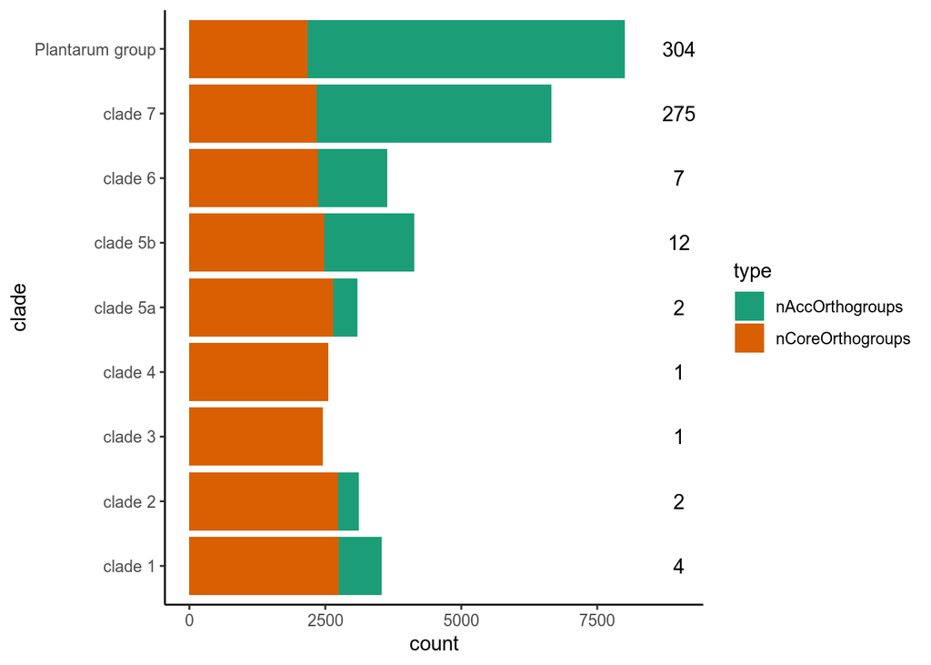

```r
plotdata <-clade_stats %>%
  select(clade, nCoreOrthogroups, nAccOrthogroups) %>%
  gather(key = "type", value = "count", -clade)

ggplot(plotdata, aes(x = clade, y = count)) +
  expand_limits(y=0) +
  geom_col(aes(fill = type)) +
  geom_text(data = clade_stats, aes(x = clade, y = 9000, label = nGenomes)) +
  coord_flip() +
  scale_fill_brewer(palette = "Dark2")  +
  theme_classic()
```

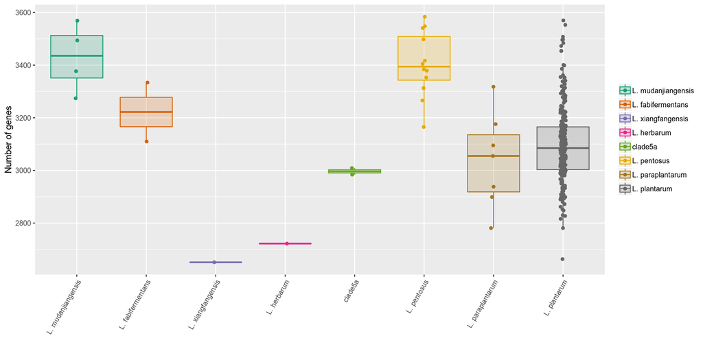

```r
plotdata <- gene_pres_abs %>%
  group_by(genome) %>%
  mutate(nOrthogroups = sum(ngenes != 0), nGenes = sum(ngenes)) %>%
  select(genome, cladeName, nOrthogroups, nGenes) %>%
  distinct() %>%
  gather(key = "type", value = "count", -genome, -cladeName)

nGenes <- plotdata %>%
  filter(type == "nGenes") %>%
  ggplot(aes(x = cladeName, y = count, fill = cladeName, group = cladeName)) +
  geom_boxplot(aes(color = cladeName), alpha = 0.20, outlier.shape =  NA) +
  geom_point(aes(col = cladeName), position = position_jitterdodge()) +
  scale_fill_brewer(palette = "Dark2") +
  scale_colour_brewer(palette = "Dark2") +
  xlab("") +
  ylab("Number of genes") +
  theme(legend.title = element_blank(),
        axis.text.x = element_text(angle = 60, hjust = 1, vjust = 1))
nGenes
```

northogroups

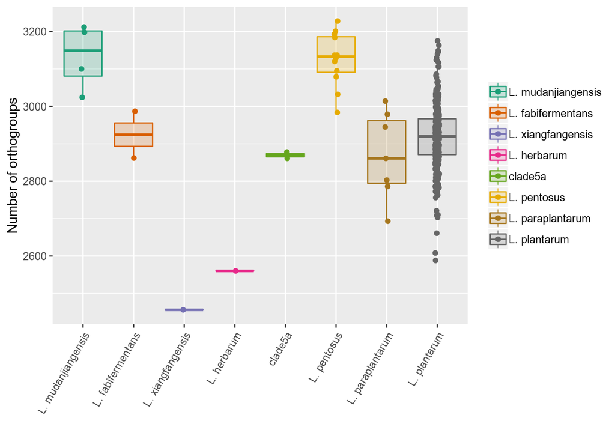

```r
nOrthogroups <- plotdata %>%
  filter(type == "nOrthogroups") %>%
  ggplot(aes(x = cladeName, y = count, fill = cladeName, group = cladeName)) +
  geom_boxplot(aes(color = cladeName), alpha = 0.20, outlier.shape =  NA) +
  geom_point(aes(col = cladeName), position = position_jitterdodge()) +
  scale_fill_brewer(palette = "Dark2") +
  scale_colour_brewer(palette = "Dark2") +
  xlab("") +
  ylab("Number of orthogroups") +
  theme(legend.title = element_blank(),
        axis.text.x = element_text(angle = 60, hjust = 1, vjust = 1))
nOrthogroups
```

Genome sizes

```r
# read quast report file
report = read.table("../03_quality_control/out/transposed_report.tsv" , header=T, sep="\t", comment.char="", quote="") %>%
  rename(genome = Assembly)
# column names: replace any number of points by one underscore
names(report) = str_replace_all(names(report), "\\.+", "_")
# column names: remove trailing underscore
names(report) = str_replace(names(report), "\\_$", "")
# column names: replace X by N (number of...)
names(report) = str_replace(names(report), "X", "N")

genomesize <- genomeTable %>%
  left_join(report) %>%
  mutate(genomesize = Total_length/1000000) %>%
  select(genome, cladeName, genomesize) %>%
  gather(key = "type", value = "count", -genome, -cladeName)
```

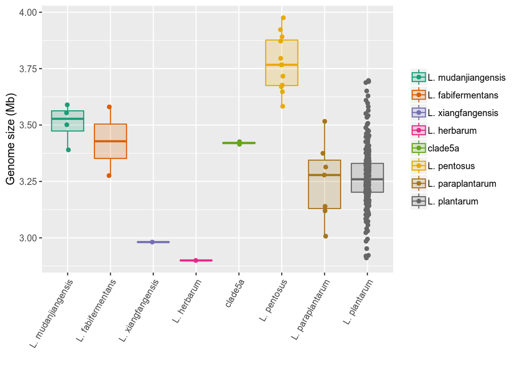

```r
genomesize_plot <- genomesize %>%
  ggplot(aes(x = cladeName, y = count, fill = cladeName)) +
  geom_boxplot(aes(color = cladeName), alpha = 0.20, outlier.shape =  NA) +
  geom_point(aes(col = cladeName), position = position_jitterdodge()) +
  scale_fill_brewer(palette = "Dark2") +
  scale_colour_brewer(palette = "Dark2") +
  xlab("") +
  ylab("Genome size (Mb)") +
  theme(legend.title = element_blank(),
        axis.text.x = element_text(angle = 60, hjust = 1, vjust = 1))
genomesize_plot
```

GC

```r
GC <- genomeTable %>%
  left_join(report) %>%
  select(genome, cladeName, GC) %>%
  gather(key = "type", value = "count", -genome, -cladeName)
```

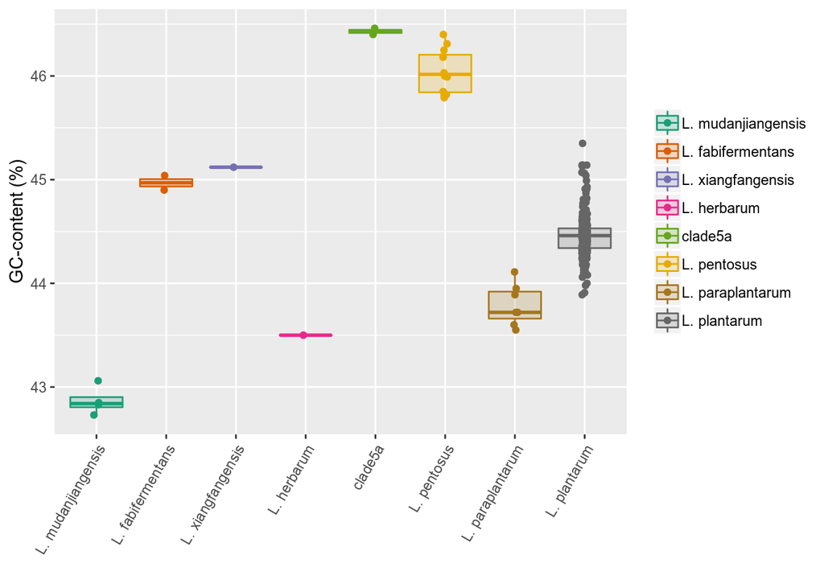

```r
gc_plot <- GC %>%
  ggplot(aes(x = cladeName, y = count, fill = cladeName)) +
  geom_boxplot(aes(color = cladeName), alpha = 0.20, outlier.shape =  NA) +
  geom_point(aes(col = cladeName), position = position_jitterdodge()) +
  scale_fill_brewer(palette = "Dark2") +
  scale_colour_brewer(palette = "Dark2") +
  xlab("") +
  ylab("GC-content (%)") +
  theme(legend.title = element_blank(),
        axis.text.x = element_text(angle = 60, hjust = 1, vjust = 1))
gc_plot
```

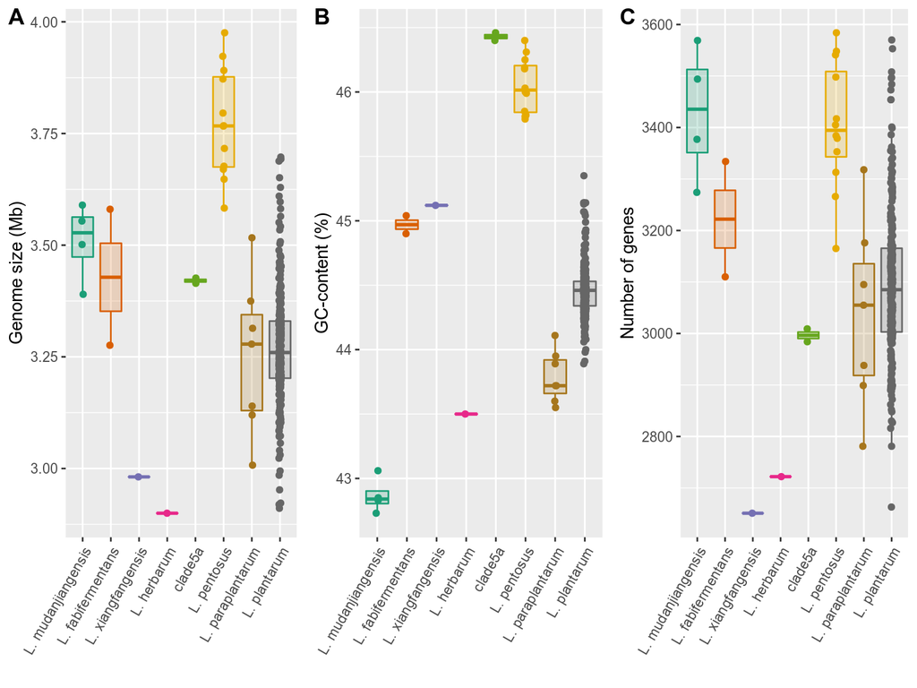

```r
ggarrange(genomesize_plot,
          gc_plot,
          nGenes,
          ncol = 3,
          legend = 'none',
          labels = "AUTO")
```

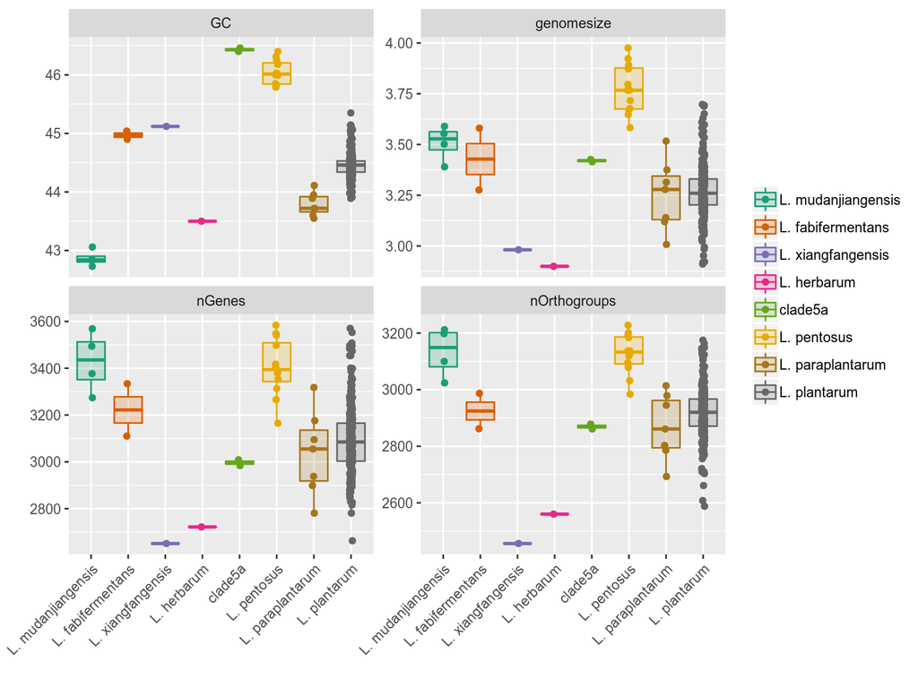

```r
plotdata %>%
  bind_rows(genomesize) %>%
  bind_rows(GC) %>%
  ggplot(aes(x = cladeName, y = count, fill = cladeName, group = cladeName)) +
  geom_boxplot(aes(color = cladeName), alpha = 0.20, outlier.shape =  NA) +
  geom_point(aes(col = cladeName), position = position_jitterdodge()) +
  scale_fill_brewer(palette = "Dark2") +
  scale_colour_brewer(palette = "Dark2") +
  xlab("") +
  ylab("") +
  theme(legend.title = element_blank(),
        axis.text.x = element_text(angle = 45, hjust = 1, vjust = 1)) +
  facet_wrap(~type, scales = "free_y")
```

# Functional analysis à la casei group paper

```r
make_pcoaTable = function(gene_pres_abs) {

  gene_pres_abs %>%
    select(orthogroup, genome, ngenes) %>%
    spread(key = orthogroup, value = ngenes, fill = 0) %>%
    remove_rownames() %>%
    column_to_rownames(var = "genome") %>%
    as.matrix() %>%
    vegdist(method = "bray") %>%
    cmdscale(k = 2) %>%
    as.data.frame() %>%
    rownames_to_column(var = "genome") %>%
    return()

}
```

## PCoA for all orthogroups

```r
# make table with pcoa coordinates for all genomes
T_pcoa1 <- make_pcoaTable(gene_pres_abs) %>%
  left_join(genomeTable)
```

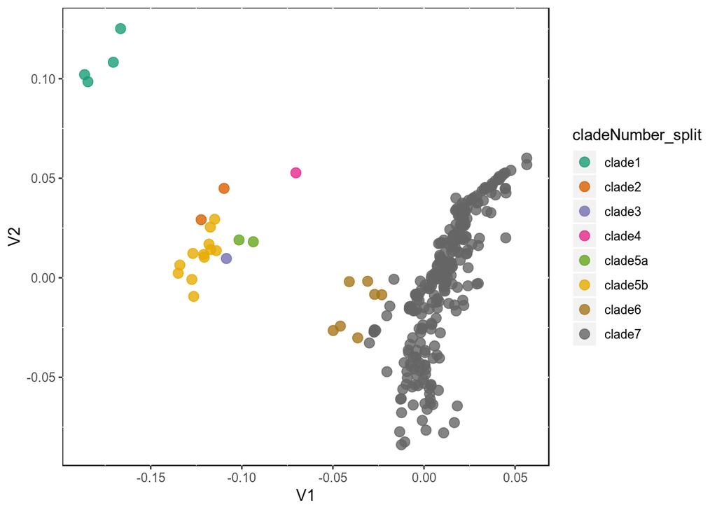

```r
# plot and save
ggplot(T_pcoa1, aes(x = V1, y = V2, col = cladeNumber_split)) +
  geom_point(size= 3 , alpha= 0.8) +
  scale_colour_brewer(palette = "Dark2") +
  theme(panel.background = element_rect(fill = 'white', colour = 'black'))
```

```r
ggsave(filename = "pcoa_overall.png", height = 20, width = 30, units = "cm")
```

## PCoA per functional category

```r
gene_pres_abs_eggnog <- gene_pres_abs %>%
  left_join(eggnog) %>%
  select(genome, orthogroup, ngenes, functCat, `eggNOG annot`) %>%
  mutate(functCat = ifelse(is.na(functCat), "S", functCat)) %>% # if function is unkown add to category S
  separate(functCat, into = c("temp1","temp2"), sep=", ", fill = "right") %>% # split rows with multiple functCats
  gather(key = "temp", value = "functCat", temp1, temp2) %>%
  select(-temp) %>%
  drop_na(functCat)
# make table with number of orthogroups per functional category
T_nOrthogroupsPerFunctCat <- gene_pres_abs_eggnog %>%
  select(orthogroup, functCat) %>%
  distinct() %>%
  group_by(functCat) %>%
  summarise(n = n()) %>%
  left_join(eggnogFunctCat) %>%
  mutate(functCatDescription = str_c(functCat, " (n = ", n, ")", "\n", str_wrap(description, width= 55)))
# do pcoa per functional category and add genome info
T_pcoa2 = gene_pres_abs_eggnog %>%
  split(f = .$functCat) %>%
  lapply(FUN = function(table) {
    if (nrow(table) <= 5) return(NULL)
    functionalCategory = table$functCat[1]
    make_pcoaTable(table) %>%
      mutate(functCat = functionalCategory) %>%
      mutate(V1 = V1 - (min(V1) + max(V1)) / 2,
             V2 = V2 - (min(V2) + max(V2)) / 2) %>%
      return()
  }) %>% bind_rows() %>%
  left_join(genomeTable) %>%
  left_join(T_nOrthogroupsPerFunctCat)
```

[output not shown]

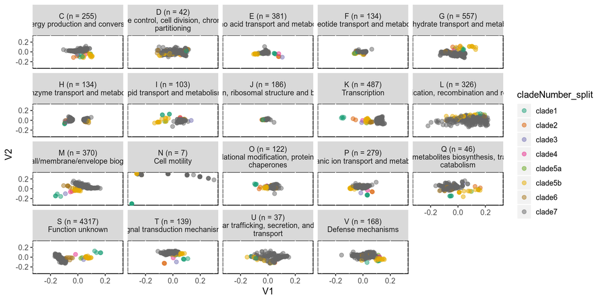

```r
# make and save plot!
ggplot(T_pcoa2, aes(x = V1, y = V2, col = cladeNumber_split)) +
  geom_point(alpha=0.5, size = 2) +
  scale_colour_brewer(palette = "Dark2") +
  facet_wrap(~ functCatDescription, ncol = 5) +
  theme(panel.background = element_rect(fill = 'white', colour = 'black'))
```

```r
ggsave(filename = "pcoa_perFunctCat.png", height = 25, width = 40, units = "cm")
```

Highlights:

- Clear difference in Energy production in clades 1-4 vs clades 5-7 -> Need to look into this!!!!!
- Similar for category E
- Clade 1 does something different for Transcirption
- Clade 1 is different in cell wall biogenesis!!!!!!
- Clade 1 is very different regarding cell motility!!!!!!!
- Clade 1 is different in Posttranslational modification
- Clade 1 is different in inorganic transport
- There’s one outlier in Q regarding clade2. need to look into this!!!! -> Does this fabifermentans do something different???

## Digging deeper in functional stuff

### Case study: Category N

There’s a difference between OGs presence abscence for category N and clade 1. Can we figure out which OGs?

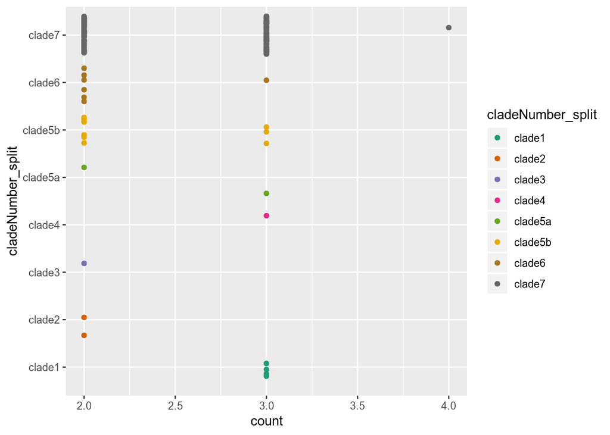

```r
cat_N <- gene_pres_abs_eggnog %>%
  filter(functCat == "N") %>%
  filter(ngenes >0)

cat_N %>%
  group_by(genome) %>%
  summarise(count = sum(ngenes > 0)) %>%
    left_join(genomeTable) %>%
  ggplot(aes(x= cladeNumber_split, y = count, col = cladeNumber_split)) +
  scale_color_brewer(palette = "Dark2") +
  geom_jitter(height = 0) +
  coord_flip()
```

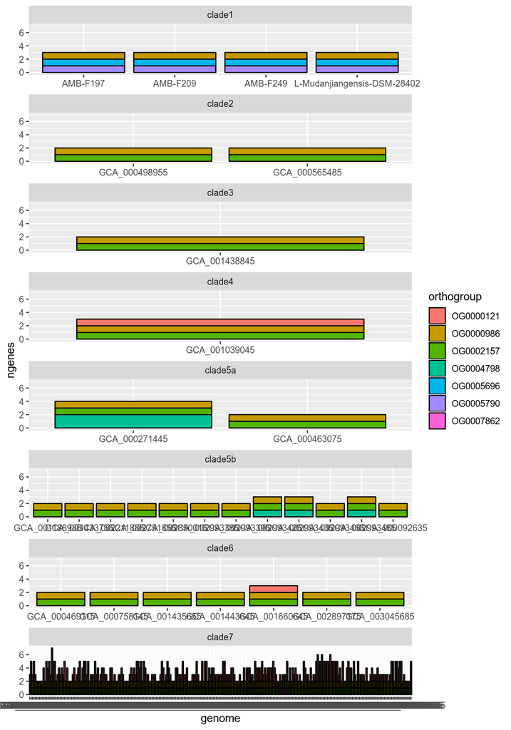

```r
cat_N %>%
  left_join(genomeTable) %>%
  ggplot(aes(x=genome, y= ngenes, fill=orthogroup)) +
  geom_bar(stat = "identity", color = "black") +
  facet_wrap(~cladeNumber_split, scales = "free_x", nrow = 8)
```

# Which are unique orthogroups?

```r
clade_unique <- gene_pres_abs %>%
  filter(ngenes > 0) %>%
  select(orthogroup, cladeNumber_split) %>%
  distinct() %>%
  add_count(orthogroup) %>%
  filter(n == 1) %>%
  select(-n) %>%
  left_join(eggnog %>% select(orthogroup, functCat, `eggNOG annot`))
clade_unique %>%
  group_by(cladeNumber_split) %>%
  summarise(count = n())
```

```
## # A tibble: 8 x 2
##   cladeNumber_split count
##   <chr>             <int>
## 1 clade1              372
## 2 clade2              213
## 3 clade3                1
## 4 clade4                1
## 5 clade5a              18
## 6 clade5b             163
## 7 clade6               82
## 8 clade7             2065
```

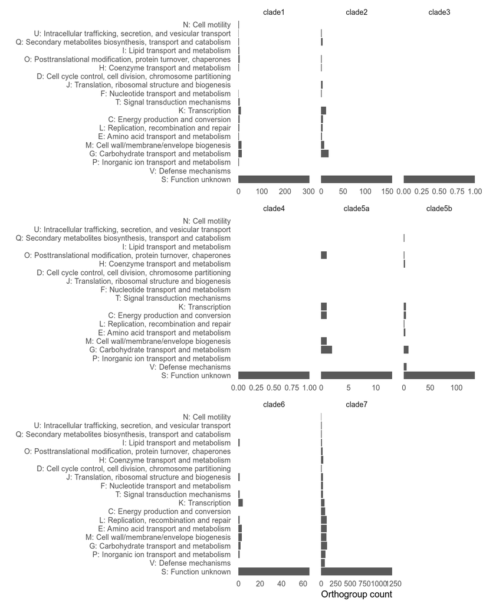

```r
clade_unique %>%
  mutate(functCat = ifelse(is.na(functCat), "S", functCat)) %>% # if function is unkown add to category S
  separate(functCat, into = c("temp1","temp2"), sep=", ", fill = "right") %>% # split rows with multiple functCats
  gather(key = "temp", value = "functCat", temp1, temp2) %>%
  select(-temp) %>%
  drop_na(functCat) %>%
  select(orthogroup, functCat, cladeNumber_split) %>%
  distinct() %>%
  group_by(functCat, cladeNumber_split) %>%
  summarise(n = n()) %>%
  left_join(eggnogFunctCat) %>%
  mutate(functCatDescription = str_c(functCat, ": ", description)) %>%
  ggplot(aes(x = reorder(functCatDescription, -n), y = n)) +
  geom_col() +
  coord_flip() +
  theme_minimal() +
  theme(panel.grid = element_blank()) +
  ylab("Orthogroup count") +
  xlab("") +
  facet_wrap(~cladeNumber_split, scales = "free_x")
```

# For clade1 only

```r
clade1_unique <- gene_pres_abs %>%
  filter(ngenes > 0) %>%
  select(orthogroup, cladeNumber_split) %>%
  distinct() %>%
  add_count(orthogroup) %>%
  filter(n == 1,
         cladeNumber_split == "clade1") %>%
  select(-n) %>%
  left_join(eggnog %>% select(orthogroup, functCat, `eggNOG annot`))
```

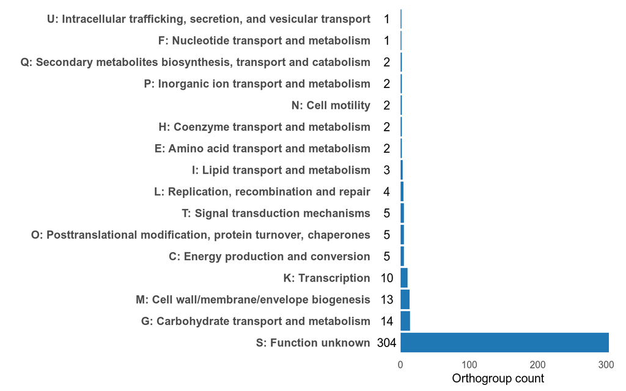

```r
clade1_unique %>%
  mutate(functCat = ifelse(is.na(functCat), "S", functCat)) %>% # if function is unkown add to category S
  separate(functCat, into = c("temp1","temp2"), sep=", ", fill = "right") %>% # split rows with multiple functCats
  gather(key = "temp", value = "functCat", temp1, temp2) %>%
  select(-temp) %>%
  drop_na(functCat) %>%
  select(orthogroup, functCat)%>%
  distinct() %>%
  group_by(functCat) %>%
  summarise(n = n()) %>%
  left_join(eggnogFunctCat) %>%
  mutate(functCatDescription = str_c(functCat, ": ", description)) %>%
  ggplot(aes(x = reorder(functCatDescription, -n), y = n)) +
  geom_col(fill = "#1f77b4") +
  geom_text(aes(y = -20, label = n)) +
  coord_flip() +
  theme_minimal() +
  theme(panel.grid = element_blank(),
        axis.text.y = element_text(face = "bold", size = 10.2)) +
  ylab("Orthogroup count") +
  xlab("")
```

Let’s dig a little bit further into these uniques

```r
# By S. Wittouck
tidy_orthofinder <- function(orthofinder_dir) {

  genes_assigned <- orthofinder_dir %>%
    paste0("/Orthogroups.csv") %>%
    readr::read_tsv(col_names = T) %>%
    rename(orthogroup = X1) %>%
    gather(key = "genome", value = "gene", na.rm = T, - orthogroup) %>%
    separate_rows(gene, sep = ", ")

}

# Read in gene info
files <- str_c("../11_gene_info/out/", list.files("../11_gene_info/out/",  pattern = "infoseq"))
names(files) <- files

genes <- map_df(files, read_tsv, skip = 1, col_names = c("gene", "Length", "%GC", "Description"), .id = "filename")  %>%
  separate(filename, "/", into = c("deleteme", "deleteme2", "deleteme3","file"), fill = "right") %>%
  separate(file, "\\.", into = c("genome", "deleteme4"), fill = "right") %>%
  select(-(starts_with("deleteme")))

# Read in orthogroup info
orthogroups <- tidy_orthofinder("~/serverUA/sander/mudan/05_pangenome/Results_Sep03/")

# Merge with uniques

clade1_unique_annot <- clade1_unique %>%
  mutate(functCat = ifelse(is.na(functCat), "S", functCat)) %>% # if function is unkown add to category S
  separate(functCat, into = c("temp1","temp2"), sep=", ", fill = "right") %>% # split rows with multiple functCats
  gather(key = "temp", value = "functCat", temp1, temp2) %>%
  select(-temp) %>%
  drop_na(functCat) %>%
  select(orthogroup, functCat)%>%
  distinct() %>%
  left_join(eggnogFunctCat) %>%
  left_join(orthogroups) %>%
  left_join(genes)
```

Unique annotations for category G

```r
clade1_unique_annot %>%
  filter(functCat == "G") %>%
  pull(Description) %>%
  unique() %>%
  kable()
```

| x |
| --- |
| MFS transporter [Lactobacillus amylovorus DSM] |
| glyceraldehyde-3-phosphate dehydrogenase [Lactobacillus paraplantarum] |
| phosphoglycerate mutase [Lactobacillus sakei] |
| Peptidoglycan N-acetylglucosamine deacetylase [Lactobacillus zymae] |
| Endoglucanase E1 |
| hypothetical protein [Lactobacillus brevis] |
| Cyanate MFS transporter [Lactobacillus zymae] |
| D-alanyl-D-alanine carboxypeptidase [Lactobacillus zymae] |
| hypothetical protein |
| 1,2-beta-oligoglucan phosphorylase |
| PTS lactose transporter subunit IIC [Lactobacillus allii] |
| hypothetical protein [Lactobacillus allii] |
| fructose-bisphosphate aldolase [Lactobacillus paracasei ATCC 334] |
| Phosphotransferase system, galactitol-specific IIB component [Lactobacillus paracasei ATCC 334] |
| hypothetical protein [Lactobacillus heilongjiangensis] |

Endoglucanase E1

https://www.ncbi.nlm.nih.gov/pmc/articles/PMC3856469/: Conversion of cellulose polymers to simple sugars requires the use of cellulases. Endoglucanases act by cleaving internal β-glycosidic bonds in the cellulose chain, thereby making chain ends accessible to cellobiohydrolase. Endoglucanases have an enzyme classification number 3.2.1.4 and belong to the broader enzyme group called glycosyl hydrolases, which also includes other cellulases such as exoglucanase and β-glucosidase. According to the CAZy database (http://www.cazy.org), endoglucanases are part of 13 distinct glycosyl hydrolase families, distributed in several archeal, bacterial, fungal, and eukaryotic organisms.

Vergelijken met onze eigen CAZYME classificatie! In AMB-F197 werd dit gen inderdaad al aangeduid als een GH5!

In discussie dieper ingaan op dit cellulose content (zie slack sarah) https://www.ncbi.nlm.nih.gov/pmc/articles/PMC3550877/

Van de rest valt weinig te zeggen

```r
clade1_unique_annot %>%
  filter(functCat == "M") %>%
  pull(Description) %>%
  unique() %>%
  kable()
```

| x |
| --- |
| hypothetical protein [Lactobacillus sp. CBA3605] |
| hypothetical protein [Lactobacillus sp. CBA3606] |
| hypothetical protein [Lactobacillus koreensis] |
| hypothetical protein [Lactobacillus pentosus] |
| hypothetical protein [Lactobacillus parabuchneri] |
| hypothetical protein [Lactobacillus brevis] |
| hypothetical protein [Lactobacillus paracollinoides] |
| N-acetylmuramoyl-L-alanine amidase [Lactobacillus koreensis] |
| glycoside hydrolase family 25 [Lactobacillus buchneri NRRL B-30929] |
| N-acetylmuramoyl-L-alanine amidase [Lactobacillus curieae] |
| hypothetical protein |
| hypothetical protein [Lactobacillus zymae] |
| beta-lactamase [Lactobacillus casei subsp. casei ATCC 393] |
| hypothetical protein [Lactobacillus allii] |

# UpsetR

Create an upset plot comparing the number of shared orthogroups per species

```r
upsetdf <- gene_pres_abs %>%
  select(orthogroup, cladeNumber_split, ngenes) %>%
  group_by(orthogroup, cladeNumber_split) %>%
  summarise(ngenes = sum(ngenes)) %>% # Sum the number of orthogroups per clade
  mutate(ngenes = if_else(ngenes > 0, 1, 0)) %>% # Convert to presence absence instead of gene count
  mutate(cladeNumber_split = case_when(cladeNumber_split == "clade1" ~ "L.mudanjiangensis",
                               cladeNumber_split == "clade2" ~ "L.fabifermentans",
                               cladeNumber_split == "clade3" ~ "L.xiangfangensis",
                               cladeNumber_split == "clade4" ~ "L.herbarum",
                               cladeNumber_split == "clade5a" ~ "clade5a",
                               cladeNumber_split == "clade5b" ~ "L.pentosus",
                               cladeNumber_split == "clade6" ~ "L.paraplantarum",
                               cladeNumber_split == "clade7" ~ "L.plantarum")) %>%
  spread(cladeNumber_split, ngenes) # Make it untidy again. What a pitty

pdf("upset.pdf", width = 12, height = 8)

upsetdf <- as.data.frame(upsetdf)
upset(upsetdf,
      sets = c("L.mudanjiangensis",
               "L.fabifermentans",
               "L.xiangfangensis",
               "L.herbarum",
               "clade5a",
               "L.pentosus",
               "L.paraplantarum",
               "L.plantarum"),
      empty.intersections = "on",
      keep.order = T,
       queries = list(
         list(query = intersects, params = list("L.mudanjiangensis"), active = T),
         list(query = intersects, params = list("L.mudanjiangensis", "L.fabifermentans"), active = T, color = "orange"),
         list(query = intersects, params = list("L.mudanjiangensis", "L.xiangfangensis"), active = T, color = "orange"),
         list(query = intersects, params = list("L.mudanjiangensis", "L.herbarum"), active = T, color = "orange"),
         list(query = intersects, params = list("L.mudanjiangensis", "clade5a"), active = T, color = "orange"),
         list(query = intersects, params = list("L.mudanjiangensis", "L.pentosus"), active = T, color = "orange"),
         list(query = intersects, params = list("L.mudanjiangensis", "L.paraplantarum"), active = T, color = "orange"),
         list(query = intersects, params = list("L.mudanjiangensis", "L.plantarum"), active = T, color = "orange"),
         list(query = intersects, params = list("L.mudanjiangensis", "L.pentosus","L.plantarum"), active = T, color = "red"),
         list(query = intersects, params = list("L.mudanjiangensis", "L.paraplantarum","L.plantarum"), active = T, color = "red")
         ),
      mainbar.y.label = "Number of orthogroups",
      sets.x.label = "Total number of orthogroups",
      point.size = 3.5,
      line.size = 2,
      text.scale = c(2, 1.5, 1.5, 1.5, 2, 1)
      )

dev.off()
```

# Mudan only

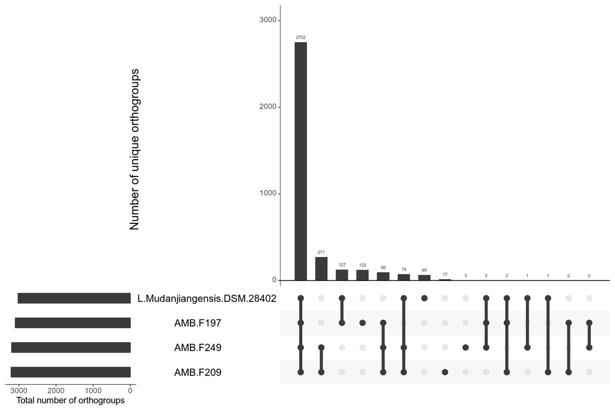

```r
upsetdf <- gene_pres_abs %>%
  filter(cladeNumber == "clade1") %>%
  select(orthogroup, genome, ngenes) %>%
  mutate(ngenes = if_else(ngenes > 0, 1, 0)) %>% # Convert to presence absence instead of gene count
  spread(genome, ngenes) # Make it untidy again. What a pitty

upsetdf <- as.data.frame(upsetdf)
upset(upsetdf,
      empty.intersections = "on",
      mainbar.y.label = "Number of unique orthogroups",
      sets.x.label = "Total number of orthogroups",
      point.size = 3.5,
      line.size = 2,
      text.scale = c(2, 1.5, 1.5, 1.5, 2, 1),
      order.by = "freq"
      )
```